# Programming Z3

Programming Z3

| Nikolaj Bjørner, Leonardo de Moura, Lev Nachmanson, and Christoph Wintersteiger Microsoft Research |
| --- |

**Abstract.** This tutorial provides a programmer's introduction to the Satisfiability Modulo Theories Solver Z3. It describes how to use Z3 through scripts, provided in the Python scripting language, and it describes several of the algorithms underlying the decision procedures within Z3. It aims to broadly cover almost all available features of Z3 and the essence of the underlying algorithms.

## 1. Introduction

Satisfiability Modulo Theories (SMT) problem is a decision problem for logical formulas with respect to combinations of background theories such as arithmetic, bit-vectors, arrays, and uninterpreted functions. Z3 is an efficient SMT solver with specialized algorithms for solving background theories. SMT solving enjoys a synergetic relationship with software analysis, verification and symbolic execution tools. This is in many respects thanks to the emphasis on supporting domains commonly found in programs and specifications. There are several scenarios where part of a query posed by these tools can be cast in terms of formulas in a supported logic. It is then useful for the tool writer to have an idea of what are available supported logics, and have an idea of how formulas are solved. But interacting with SMT solvers is not always limited to posing a query as a single formula. It may require a sequence of interactions to obtain a usable answer and the need emerges for the tool writer for having an idea of what methods and knobs are available. In summary, this tutorial aims to answer the following types of questions through examples and a touch of theory:

- What are the available features in Z3, and what are they designed to be used for?
- What are the underlying algorithms used in Z3?
- How can I program applications on top of Z3?

Figure 1 shows an overall systems diagram of Z3, as of version 4.8. The top left summarizes the interfaces to Z3. One can interact with Z3 over SMT-LIB2 scripts supplied as a text file or pipe to Z3, or using API calls from a high-level programming language that are proxies for calls over a C-based API. We focus on using the Python front-end as a means of interfacing with Z3, and start out describing the abstract syntax of terms and formulas accepted by Z3 in Section 2. Formulas draw from symbols whose meaning are defined by a set of *Theories*, Section 3. *Solvers*, Sections 4, 5 and 6, provide services for deciding satisfiability of formula. *Tactics*, Section 7, provide means for pre-processing simplification and creating sub-goals. Z3 also provides some services that are not purely satisfiability queries. *Optimization*, Section 8, services allow users to solve satisfiability modulo objective functions to maximize or minimize values. There are also specialized procedures for enumerating *consequences* (backbone literals) described in Section 4.6.6.

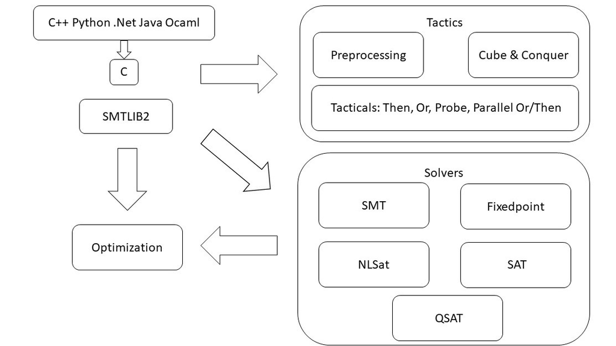

**Figure 1.** Overall system architecture of Z3

### 1.1. Resources

The main point of reference for Z3 is the GitHub repository

[https://github.com/z3prover/z3](https://github.com/z3prover/z3)

Examples from this tutorial that are executable can be found on

[https://github.com/Z3Prover/doc/tree/master/programmingz3/code](https://github.com/Z3Prover/doc/tree/master/programmingz3/code)

There are several systems that program with Z3. They use a variety of front-ends, some use OCaml, others C++, and others use the SMT-LIB2 text interfaces. A few instances that use the Python front-end include

- Dennis Yurichev assembled a significant number of case studies drawn from puzzles and code analysis and presents many of the examples using the Python front-end [https://yurichev.com/writings/SAT_SMT_by_example.pdf](https://yurichev.com/writings/SAT_SMT_by_example.pdf).
- The Ivy system is written in Python and uses Z3

  [https://github.com/Microsoft/ivy](https://github.com/Microsoft/ivy).
- The binary analysis kit Angr system is written in Python and uses Z3

  [https://docs.angr.io/](https://docs.angr.io/).
- There is an online tutorial of z3

  [https://microsoft.github.io/z3guide](https://microsoft.github.io/z3guide).

### 1.2. Sources

The material in this tutorial is assembled from several sources. Some of the running examples originate from slides that have circulated in the SAT and SMT community. The first SAT example is shamelessly lifted from Armin Biere's SAT tutorials and other examples appear in slides by Natarajan Shankar.

## 2. Logical Interfaces to Z3

Z3 takes as input simple-sorted formulas that may contain symbols with pre-defined meanings defined by a *theory*. This section provides an introduction to logical formulas that can be used as input to Z3.

As a basis, propositional formulas are built from atomic variables and logical connectives. An example propositional logical formula accepted by Z3 is:

```python
  from z3 import *
  Tie, Shirt = Bools('Tie Shirt')
  s = Solver()
  s.add(Or(Tie, Shirt),
        Or(Not(Tie), Shirt),
        Or(Not(Tie), Not(Shirt)))
  print(s.check())
  print(s.model())
```

The example introduces two Boolean variables `Tie` and `Shirt`. It then creates a `Solver` object and adds three assertions.

[figure not shown]

The call to `s.check()` produces a verdict `sat`; there is a satisfying assignment for the formulas. A satisfying model, where `Tie` is false and `Shirt` is true, can be extracted using `s.model()`. For convenience the Python front-end to Z3 contains some shorthand functions. The function `solve` sets up a solver, adds assertions, checks satisfiability, and prints a model if one is available.

Propositional logic is an important, but smaller subset of formulas handled by Z3. It can reason about formulas that combine symbols from several theories, such as the theories for arrays and arithmetic:

```python
  Z = IntSort()
  f = Function('f', Z, Z)
  x, y, z = Ints('x y z')
  A = Array('A', Z, Z)
  fml = Implies(x + 2 == y, f(Store(A, x, 3)[y - 2]) == f(y - x + 1))
  solve(Not(fml))
```

The formula `fml` is valid. It is true for all values of integers *x*, *y*, *z*, array *A*, and no matter what the graph of the function *f* is. Note that *z* does not even occur in the formula, but we declare it here because we will use *z* to represent an integer variable. Note that we are using `array[index]` as shorthand for `Select(array, index)`. We can manually verify the validity of the formula using the following argument: The integer constants `x` and `y` are created using the function `Ints` that creates a list of integer constants. Under the assumption that `x + 2 = y`, the right side of the implication simplifies to

```python
f(Store(A, x, 3)[x]) == f(3)
```

as we have replaced occurrences of `y` by `x + 2`. There are no restrictions on what `f` is, so the equality with `f` on both sides will only follow if the arguments to `f` are the same. Thus, we are left to establish

```python
Store(A, x, 3)[x] == 3
```

The left side is a term in the theory of arrays, which captures applicative maps. `Store` updates the array `A` at position `x` with the value 3. Then `...[x]` retrieves the contents of the array at index `x`, which in this case is 3. Dually, the *negation* of `fml` is unsatisfiable and the call to Z3 produces `unsat`.

Formulas accepted by Z3 generally follow the formats described in the SMT-LIB2 standard [4]. This standard (currently at version 2.6) defines a textual language for first-order multi-sorted logic and a set of *logics* that are defined by a selection of background theories. For example, the logic of *quantifier-free linear integer arithmetic*, known in SMT-LIB2 as `QF_LIA`, is a fragment of first-order logic, where formulas are *quantifier free*, variables range over integers, interpreted constants are integers, the allowed functions are *+*, *-*, integer multiplication, division, remainder, modulus with a constant, and the allowed relations are, besides equality that is part of every theory, also *<, <=, >=, >*. As an example, we provide an SMT-LIB and a Python variant of the same arbitrary formula:

```
 (set-logic QF_LIA)
 (declare-const x Int)
 (declare-const y Int)
 (assert (> (+ (mod x 4) (* 3 (div y 2))) (- x y)))
 (check-sat)
```

Python version:

```python
 solve((x % 4) + 3 * (y / 2) > x - y)
```

It is also possible to extract an SMT-LIB2 representation of a solver state.

```python
from z3 import *
x, y = Ints('x y')
s = Solver()
s.add((x % 4) + 3 * (y / 2) > x - y)
print(s.sexpr())
```

produces the output

```
(declare-fun y () Int)
(declare-fun x () Int)
(assert (> (+ (mod x 4) (* 3 (div y 2))) (- x y)))
```

### 2.1. Sorts

Generally, SMT-LIB2 formulas use a finite set of simple sorts. It includes the built-in sort `Bool`, and supported theories define their own sorts, noteworthy `Int`, `Real`, bit-vectors `(_ BitVec n)` for every positive bit-width *n*, arrays  
`(Array Index Elem)` for every sort *Index* and *Elem*, `String` and sequences `(Seq S)` for every sort *S*. It is also possible to declare new sorts. Their domains may never be empty. Thus, the formula

```python
 S = DeclareSort('S')
 s = Const('s', S)
 solve(ForAll(s, s != s))
```

is unsatisfiable.

### 2.2. Signatures

Formulas may include a mixture of interpreted and free functions and constants. For example, the integer constants 0 and 28 are interpreted, while constants *x*, *y* used in the previous example are free. Constants are treated as nullary functions. Functions that take arguments can be declared, such as `f = Function('f', Z, Z)` creates the function declaration that takes one integer argument and its range is an integer. Functions with Boolean range can be used to create formulas.

### 2.3. Terms and Formulas

Formulas that are used in assertions or added to solvers are terms of Boolean sort. Otherwise, terms of Boolean and non-Boolean sort may be mixed in any combination where sorts match up. For example

```python
B = BoolSort()
f = Function('f', B, Z)
g = Function('g', Z, B)
a = Bool('a')
solve(g(1+f(a)))
```

could produce a solution of the form

```python
[a = False, f = [else -> 0], g = [else -> True]]
```

The model assigns `a` to False, the graph of `f` maps all arguments to `0`, and the graph of `g` maps all values to `True`. Standard built-in logical connectives are `And, Or, Not, Implies, Xor`. Bi-implication is a special case of equality, so from Python, when saying `a == b` for Boolean *a* and *b* it is treated as a logical formula for the bi-implication of *a* and *b*.

A set of utilities are available to traverse expressions once they are created. Every function application has a function *declaration* and a set of *arguments* accessed as children.

```python
x = Int('x')
y = Int('y')
n = x + y >= 3
print("num args: ", n.num_args())
print("children: ", n.children())
print("1st child:", n.arg(0))
print("2nd child:", n.arg(1))
print("operator: ", n.decl())
print("op name:  ", n.decl().name())
```

### 2.4. Quantifiers and Lambda binding

Universal and existential quantifiers bind variables to the scope of the quantified formula. For example

```python
solve([y == x + 1, ForAll([y], Implies(y <= 0, x < y))])
```

has no solution because no matter what value we assigned to `x`, there is a value for `y` that is non-positive and smaller than that value. The bound occurrence of `y` is unrelated to the free occurrence where `y` is restricted to be `x + 1`. The equality constraint `y == x + 1` should also not be mistaken for an assignment to `y`. It is *not* the case that bound occurrences of `y` are a synonym for `x + 1`. Notice that the slightly different formula

```python
solve([y == x + 1, ForAll([y], Implies(y <= 0, x > y))])
```

has a solution where *x* is 1 and the free occurrence of *y* is 2.

```python
m, m1 = Array('m', Z, Z), Array('m1', Z, Z)
def memset(lo, hi, y, m):
    return Lambda([x], If(And(lo <= x, x <= hi), y, Select(m, x)))
solve([m1 == memset(1, 700, z, m), Select(m1, 6) != z])
```

Lambda binding is convenient for creating closures. Recall that meaining of `Lambda([x,y], e)`, where `e` is an expression with free occurrences of `x` and `y` is as a function that takes two arguments and substitutes their values for `x` and `y` in `e`. Z3 uses Lambda lifting, in conjunction with Reynold's defunctionalization, to reduce reasoning about closures to universally quantified definitions. Z3 treats arrays as general function spaces. All first-order definable functions may be arrays. Some second-order theorems can be established by synthesizing terms by instantiation. Thus,

```python
Q = Array('Q', Z, B)
prove(Implies(ForAll(Q, Implies(Select(Q, x), Select(Q, y))),
              x == y))
```

is provable. Z3 synthesizes an instantiation corresponding to `Lambda(z, z == x)` for *Q*.

## 3. Theories

We will here summarize the main theories supported in Z3. In a few cases we will give a brief taste of decision procedures used for these theories. Readers who wish to gain a more in-depth understanding of how these decision procedures are implemented may follow some of the citations.

### 3.1. EUF: Equality and Uninterpreted Functions

The logic of *equality and uninterpreted function*, EUF, is a basic ingredient for first-order predicate logic. Before there are theories, there are constants, functions and predicate symbols, and the built-in relation of equality. In the following example, *f* is a unary function, *x* a constant. The first invocation of `solve` is feasible with a model where *x* is interpreted as an element in *S* and *f* is an identify function. The second invocation of *solve* is infeasible; there are no models where *f* maps *x* to anything but itself given the two previous equalities.

```python
  S = DeclareSort('S')
  f = Function('f', S, S)
  x = Const('x', S)
  solve(f(f(x)) == x, f(f(f(x))) == x)
  solve(f(f(x)) == x, f(f(f(x))) == x, f(x) != x)
```

Decision procedures for quantifier-free EUF formulas are usually based on *union-find* [59] to maintain equivalence classes of terms that are equated. Pictorially, a sequence of equality assertions produce one equivalence class that captures the transitivity of equality.

[figure not shown]

It is possible to check for satisfiability of disequalities by checking whether the equivalence classes associated with two disequal terms are the same or not. Thus, adding does not produce a contradiction, and it can be checked by comparing 's class representative with 's representative.

[figure not shown]

On the other hand, when asserting , we can deduce a conflict as the two terms asserted to be disequal belong to the same class. Class membership with union-find data-structures is amortized nearly constant time.

[figure not shown]

Union-find alone is insufficient when function symbols are used, as with the following example,

[figure not shown]

In this case decision procedures require reasoning with the congruence rule

As a preparation for solving our example, let us introduce constants that can be used as shorthands for sub-terms. Thus, introduce constants as representatives for the four compound sub-terms.

[figure not shown]

Having only the equality information available we obtain the equivalence classes:

[figure not shown]

Working bottom-up, the congruence rule dictates that the classes for and should be merged. Thus,

implies the following coarser set of equivalences.

[figure not shown]

At this point, the congruence rule can be applied a second time,

producing the equivalence classes

[figure not shown]

The classes for and are now merged. As our original formula required these to be distinct, congruence closure reasoning determines that the formula is unsatisfiable.

#### 3.1.1. Congruence Closure

We have implicitly used the notion of *congruence closure* [27] to check satisfiability of equalities. Let us more formally define this notion. Let be a set of terms and set of equalities over . A *congruence closure* over modulo is the finest partition of , such that:

- if , then are in the same partition in .
- for

[figure not shown]

  ,
  - if are in same partition of for each ,
  - then are in the same partition under .

**Definition 1.**  
, maps term to its equivalence class.

#### 3.1.2. EUF Models

A satisfiable version of the running example is:

[figure not shown]

It induces the following definitions and equalities:

[figure not shown]

and we can associate a distinct value with each equivalence class.

[figure not shown]

When presenting the formula to Z3 as

```python
S = DeclareSort('S')
a, b, c, d, e, s, t = Consts('a b c d e s t', S)
f = Function('f', S, S, S)
g = Function('g', S, S)
solve([a == b, b == c, d == e, b == s,
       d == t, f(a, g(d)) != f(g(e), b)])
```

it produces a model, that may look as follows:

```python
[s = S!val!0, b = S!val!0, a = S!val!0,
 c = S!val!0, d = S!val!1, e = S!val!1, t = S!val!1,
 f = [(S!val!2, S!val!0) -> S!val!4, else -> S!val!3],
 g = [else -> S!val!2]]
```

In the model the value `S!val!0` is a fresh constant that is distinct from `S!val!1`. The graph for `f` maps the arguments `(S!val!2, S!val!0)` to `S!val!4`. All other arguments are mapped by the `else` clause to `S!val!3`. The `else` clause is used as the default interpretation of arguments that are not listed in the interpretation. The interpretation of *S* is a finite set

```python
    {S!val!0, S!val!1, S!val!2, S!val!3, S!val!4}.
```

### 3.2. Arithmetic

Arithmetical constraints are nearly ubiquitous in software models. Even though mainstream software operates with finite precision arithmetic, that is modeled precisely using bit-vectors, arithmetic over unbounded integers can often be used in a sound way to model software. Furthermore, arithmetic over the reals has been used for diverse areas such as models of cyber-physical systems or for axiomatic economics.

#### 3.2.1. Solving LRA: Linear Real Arithmetic

We provide an outline of Z3's main procedure for solving formulas over linear real arithmetic [28]. It maintains a (dual) Simplex tableau that encodes equalities of the form . Feasibility of the equalities depends on bounds, , currently associated with the variables. For the following formula

```python
  x, y = Reals('x y')
  solve([x >= 0, Or(x + y <= 2, x + 2*y >= 6),
                 Or(x + y >= 2, x + 2*y > 4)])
```

Z3 introduces auxiliary variables and represents the formula as

[figure not shown]

Only bounds (e.g., ) are asserted during search.

The first two equalities form the tableau. Thus, the definitions produce the equalities

They are equivalent to the normal form:

where are basic (dependent) and are non-basic. In dual Simplex tableaux, values of a non-basic variable can be chosen between and . The value of a basic variable is a function of non-basic variable values. It is the unique value that satisfies the unique row where the basic variable occurs. Pivoting swaps basic and non-basic variables and is used to get values of basic variables within bounds. For example, assume we start with a set of initial values and bounds . Then has to be 2 and it is made non-basic. Instead becomes basic:

The new tableau updates the assignment of variables to . The resulting assignment is a model for the original formula.

#### 3.2.2. Solving Arithmetical Fragments

The solvers available to reason about arithmetical constraints are wildly different depending on what fragments of arithmetic is used. We summarize the main fragments, available decision procedures, and examples in Table 1 where range over reals and range over integers.

| Logic | Description | Solver | Example |
| --- | --- | --- | --- |
| LRA | Linear Real Arithmetic | Dual Simplex [28] |  |
| LIA | Linear Integer Arithmetic | Cuts + Branch |  |
| LIRA | Mixed Real/Integer | [7, 12, 14, 26, 28] |  |
| IDL | Integer Difference Logic | Floyd-Warshall |  |
| RDL | Real Difference Logic | Bellman-Ford |  |
| UTVPI | Unit two-variable / inequality | Bellman-Ford |  |
| NRA | Polynomial Real Arithmetic | Model based CAD [42] |  |
| NIA | Non-linear Integer Arithmetic | CAD + Branch [41] |  |
|  |  | Linearization [15] |  |

**Table 1.** Arithmetic Theories

There are many more fragments of arithmetic that benefit from specialized solvers. We later discuss some of the fragments where integer variables are restricted to the values when describing Pseudo-Boolean constraints. Other fragments that are *not* currently handled in Z3 in any special way include fragments listed in Table 2.

| Description | Example |
| --- | --- |
| Horn Linear Real Arithmetic |  |
| At most one variable is positive |  |
| Two-variable per inequality [16] |  |
| Min-Horn [18] |  |
| Bi-linear arithmetic |  |
| Transcendental functions |  |
| Modular linear arithmetic |  |

**Table 2.** Fragments of Arithmetic

A user of Z3 may appreciate that a domain can be modeled using a fragment of the theory of arithmetic that is already supported, or belongs to a class where no special support is available. On a practical side, it is worth noting that Z3 uses infinite precision arithmetic by default. Thus, integers and rationals are represented without rounding. The benefit is that the representation ensures soundness of the results, but operations by decision procedures may end up producing large numerals taking most of the execution time. Thus, users who produce linear arithmetic constraints with large coefficients or long decimal expansions may face performance barriers.

### 3.3. Arrays

The declaration

```python
  A = Array('A', IntSort(), IntSort())
```

introduces a constant `A` of the array sort mapping integers to integers. We can solve constraints over arrays, such as

```python
solve(A[x] == x, Store(A, x, y) == A)
```

which produces a solution where `x` necessarily equals `y`.

Z3 treats arrays as function spaces, thus a function `f(x, y)` can be converted to an array using a

```python
  Lambda([x, y], f(x, y))
```

If `f` has sort , then `Lambda([x, y], f(x, y))` has sort `Array(A, B, C)`. A set of built-in functions are available for arrays. We summarize them together with their representation using `Lambda` bindings.

```python
  a[i]             # select array 'a' at index 'i'
                   # Select(a, i)

  Store(a, i, v)   # update array 'a' with value 'v' at index 'i'
                   # = Lambda(j, If(i == j, v, a[j]))

  K(D, v)          # constant Array(D, R), where R is sort of 'v'.
                   # = Lambda(j, v)

  Map(f, a)        # map function 'f' on values of 'a'
                   # = Lambda(j, f(a[j]))

  Ext(a, b)        # Extensionality
                   # Implies(a[Ext(a, b)] == b[Ext(a, b)], a == b)
```

#### 3.3.1. Deciding Arrays by Reduction to EUF

Formulas using the combinators `Store, K, Map, Ext` are checked for satisfiability by *expanding* the respective definitions on sub-terms. We illustrate how occurrences of `Store` produce constraints over EUF. In the following, assume we are given a solver `s` with ground assertions using arrays.

For each occurrence in `s` of `Store(a, i, v)` and `b[j]`, add the following assertions:

- `s.add(Store(a, i, v)[j] == If(i == j, v, a[j]))`
- `s.add(Store(a, i, v)[i] == v)`

The theory of arrays is *extensional*. That is, two arrays are equal if they behave the same on all selected indices. When Z3 produces models for quantifier free formulas in the theory of extensional arrays it ensures that two arrays are equal in a model whenever they behave the same on all indices. Extensionality is enforced on array terms , in `s` by instantiating the axiom of extensionality.

- `s.add(Implies(ForAll(i, a[i] == b[i]), a == b))`

Since the universal quantifier occurs in a negative polarity we can introduce a Skolem function `Ext` that depends on `a` and `b` and represent the extensionality requirement as:

- `s.add(Implies(a[Ext(a, b)] == b[Ext(a, b)], a == b))`

We can convince ourselves that asserting these additional constraints force models of a solver `s` to satisfy the array axioms. Suppose we are given a model satisfying all the additional asserted equalities. These equalities enforce the axioms for `Store` on all indices that occur in `s`. They also enforce extensionality between arrays: Two arrays are equal if and only if they evaluate to the same value on all indices in `s`.

### 3.4. Bit-Vectors

Let us play with some bit-fiddling. The resource

[https://graphics.stanford.edu/~seander/bithacks.html](https://graphics.stanford.edu/~seander/bithacks.html),

lists a substantial repertoire of bit-vector operations that can be used as alternatives to potentially more expensive operations. Note that modern compilers already contain a vast set of optimizations that automatically perform these conversions and Z3 can be used to check and synthesize such optimizations [46]. For example, to test whether a bit-vector is a power of two we can use a combination of bit-wise operations and subtraction:

```python
def is_power_of_two(x):
    return And(x != 0, 0 == (x & (x - 1)))
x = BitVec('x', 4)
prove(is_power_of_two(x) == Or([x == 2**i for i in range(4)]))
```

The absolute value of a variable can be obtained using addition and xor with a sign bit.

```python
v = BitVec('v',32)
mask = v >> 31
prove(If(v > 0, v, -v) == (v + mask) ^ mask)
```

Notice that the Python variable `mask` corresponds to the expression `v >> 31`, the right arithmetic (signed) shift of `v`. Notice also, that in classical first-order logic, all operations are *total*. In particular, for bit-vector arithmetic `-v` is fully specified, in contrast to, say C, which specifies that `-v` is *undefined* when `v` is a signed integer with the value .

#### 3.4.1. Solving bit-vectors

Z3 mostly uses a bit-blasting approach to deciding bit-vectors. By bit-blasting we refer to a reduction of bit-vector constraints to propositional logic by treating each bit in a bit-vector as a propositional variable. Let us illustrate how bit-vector addition is compiled to a set of clauses. The expression `v + w`, where `v` and `w` are bit-vectors is represented by a vector `out` of output bits. The relation between `v`, `w` and `out` is provided by clauses the encode a ripple-carry adder seen in Figure 2. The encoding uses an auxiliary vector of *carry bits* that are internal to the adder.

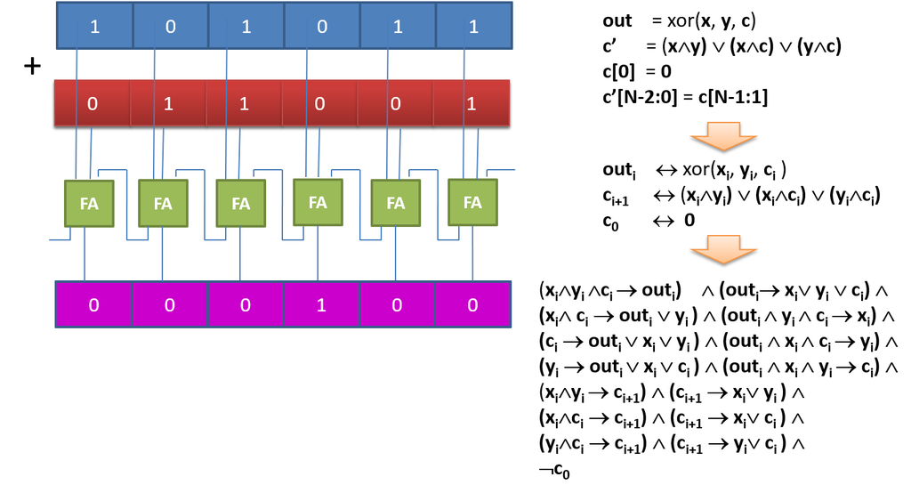

**Figure 2.** Bit-vector addition circuit

#### 3.4.2. Floating Point Arithmetic

Floating points are bit-vectors with an interpretation specified by the IEEE floating point standard.

```python
x = FP('x', FPSort(3, 4))
print(10 + x)
```

It declares a floating point number `x` with 3 bits in the exponent and 4 for the significand. The result of adding 10 to `x` is `1.25*(2**3) + x`. We see that 10 is represented as a floating point number with exponent 3, that is the bit-vector 011. The significand is 1010.

### 3.5. Algebraic Datatypes

The theory of first-order algebraic data-types captures the theory of finite trees. It is characterized by the properties that:

- All trees are finite (occurs check).
- All trees are generated from the constructors (no junk).
- Two trees are equal if and only if they are constructed exactly the same way (no confusion).

A basic example of a binary tree data-type is given in Figure 3.

```python
Tree = Datatype('Tree')
Tree.declare('Empty')
Tree.declare('Node', ('left', Tree), ('data', Z), ('right', Tree))
Tree = Tree.create()
t = Const('t', Tree)
solve(t != Tree.Empty)
```

**Figure 3.** Binary tree datatypes

It may produce the solution

```python
[t = Node(Empty, 0, Empty)]
```

Similarly, one can prove that a tree cannot be a part of itself.

```python
prove(t != Tree.Node(t, 0, t))
```

### 3.6. Sequences and Strings

The theory of strings and sequences extend on the theory of the free monoid with a few additional functions that are useful for strings and sequences. A length operation is built-in for strings and sequences, and there are operations for converting strings to natural numbers and back.

If the lengths of a prefix and suffix of a string add up to the length of the string, the string itself must be the concatenation of the prefix and suffix:

```python
s, t, u = Strings('s t u')
prove(Implies(And(PrefixOf(s, t), SuffixOf(u, t),
                  Length(t) == Length(s) + Length(u)),
             t == Concat(s, u)))
```

One can concatenate single elements to a sequence as units:

```python
s, t = Consts('s t', SeqSort(IntSort()))
solve(Concat(s, Unit(IntVal(2))) == Concat(Unit(IntVal(1)), t))
prove(Concat(s, Unit(IntVal(2))) != Concat(Unit(IntVal(1)), s))
```

There are two solvers available in Z3 for strings. They can be exchanged by setting the parameter

- `s.set("smt.string_solver","seq")` with contributions by Thai Trinh, or
- `s.set("smt.string_solver","z3str3")` by Murphy Berzish.

### 3.7. Special Relations

In some cases it is possible to use first-order axioms to capture all required properties of relations. For example, to say that `R` is a partial order it suffices to assert the axioms:

```python
  s = Solver()
  A = DeclareSort("A")
  R = Function('R', A, A, B)
  x, y, z = Consts('x y z', A)
  s.add(ForAll([x], R(x, x)))
  s.add(ForAll([x,y], Implies(And(R(x, y), R(y, x)), x == y)))
  s.add(ForAll([x,y,z], Implies(And(R(x, y), R(y, z)), R(x, z))))
  # and other assertions using R
```

The catch is that reasoning about `R` often requires instantiating the full transitive closure of the relation. This is impractical when the number of instances can lead to a quadratic overhead compared to the size of the initial constraints. For example, when asserting `s.add(R(a1,a2),R(a2,a3),...,R(a999,a1000))` we obtain half a million instances. Instead of axiomatizing a relation to be a partial ordering, Z3 allows to declare a relation that as a built-in property satisfies the partial ordering axioms. Thus, the definition

```python
  R = PartialOrder(A, 0)
```

creates a binary relation `R` over `A` that satisfies the partial order axioms. The second argument is an unsigned integer used to distinguish the partial order `R` from other partial order relations over the same signature. Thus `PartialOrder(A, 2)` creates a partial ordering relation that is different from `R` because it uses a different index. As usual, other properties of the relation have to be added to the solver `s`. The built-in decision procedure for partial orders avoids the quadratic instantiation from the transitive closure axiom. It reasons about graph reachability to check consistency of assertions involving `R`.

Other binary relations that have special relations support are Total Linear orders:

```python
  s.Add(ForAll([x], R(x, x)))
  s.Add(ForAll([x,y], Implies(And(R(x, y), R(y, x)), x == y)))
  s.Add(ForAll([x,y,z], Implies(And(R(x, y), R(y, z)), R(x, z))))
  s.Add(ForAll([x,y], Or(R(x, y), R(y, x))))

# use instead:

  R = LinearOrder(A, 0)
```

Tree-like orderings:

```python
  s.Add(ForAll([x], R(x, x)))
  s.Add(ForAll([x,y], Implies(And(R(x, y), R(y, x)), x == y)))
  s.Add(ForAll([x,y,z], Implies(And(R(x, y), R(y, z)), R(x, z))))
  s.Add(ForAll([x,y,z], Implies(And(R(x, y), R(x, z)), Or(R(y, z), R(z, y)))))

# use instead:

  R = TreeOrder(A, 0)
```

Piecewise Linear orders:

```python
  s.Add(ForAll([x], R(x, x)))
  s.Add(ForAll([x,y], Implies(And(R(x, y), R(y, x)), x == y)))
  s.Add(ForAll([x,y,z], Implies(And(R(x, y), R(y, z)), R(x, z))))
  s.Add(ForAll([x,y,z], Implies(And(R(x, y), R(x, z)), Or(R(y, z), R(z, y)))))
  s.Add(ForAll([x,y,z], Implies(And(R(y, x), R(z, x)), Or(R(y, z), R(z, y)))))

# use instead:
  R = PiecewiseLinearOrder(A, 0)
```

Additional examples of special relations constraints are [available online](https://github.com/Z3Prover/doc/blob/master/programmingz3/code/special_relations.py).

### 3.8. Transitive Closure

The transitive closure of a relation is a property that cannot be fully axiomatized using first-order formalisms. Quantifier-free formulas using the transitive closure of relations remain decidable, however, using a finite model construction. Given a relation binary `R`, the *transitive closure* of `R` is another relation `TC_R` that relates two elements by if there is a non-empty path that connect them through `R`. To create a transitive closure or transitive reflexive closure of `R`.

```python
  R = Function('R', A, A, B)
  TC_R = TransitiveClosure(R)
  s = Solver()
  a, b, c = Consts('a b c', A)
  s.add(R(a, b))
  s.add(R(b, c))
  s.add(Not(TC_R(a, c)))
  print(s.check())   # produces unsat
```

## 4. Interfacing with Solvers

Solvers maintain a set of formulas and supports satisfiability checking, and scope management: Formulas that are added under one scope can be retracted when the scope is popped. In this section we describe the interface to solvers. Section 5 provides a set of use cases and section 6 describes the underlying solver implementations available in Z3.

### 4.1. Incrementality

Solvers can be used to check satisfiability of assertions in an incremental way. An initial set of assertions can be checked for satisiability followed by additional assertions and checks. Assertions can be retracted using scopes that are pushed and popped. Under the hood, Z3 uses a one-shot solver during the first check. If further calls are made into the solver, the default behavior is to switch to an *incremental* solver. The incremental solver uses the SMT core, see 6.1, by default. For use-cases that don't require all features by the SMT core, it may be beneficiary to use specialized solvers, such as solvers for finite domains (bit-vectors, enumeration types, bounded integers, and Booleans) as specified using the `QF_FD` logic.

### 4.2. Scopes

The operations `push` and `pop` create, respectively revert, local scopes. Assertions that are added within a `push` are retracted on a matching `pop`. Thus, the following session results in the verdicts `sat`, `unsat`, and `sat`.

```python
p, q, r = Bools('p q r')
s = Solver()
s.add(Implies(p, q))
s.add(Not(q))
print(s.check())
s.push()
s.add(p)
print(s.check())
s.pop()
print(s.check())
```

### 4.3. Assumptions

Alternative to scopes, it is possible to check satisfiability under the assumption of a set of literals. Thus, the session

```python
s.add(Implies(p, q))
s.add(Not(q))
print(s.check(p))
```

also produces the verdict `unsat` as the conjunction of , , is `unsat`. The method `assert_and_track(q, p)` has the same effect of adding `Implies(p, q)`, and it adds `p` as an implicit assumption. Our running example becomes

```python
p, q = Bools('p q')
s = Solver()
s.add(Not(q))
s.assert_and_track(q, p)
print(s.check())
```

### 4.4. Cores

We can extract a subset of assumptions used to derive unsatisfiability. Such subsets of assumptions are known as *unsatisfiable cores*, or simply as a *core*. In the following example, the unsatisfiable core has the single element `p`. The unrelated assumption `v` does not appear in the core.

```python
p, q, r, v = Bools('p q r v')
s = Solver()
s.add(Not(q))
s.assert_and_track(q, p)
s.assert_and_track(r, v)
print(s.check())
print(s.unsat_core())
```

Note that we invoke `s.check()` prior to extracting a core. Cores are only available after the last call to `s.check()` produced `unsat`.

By default solvers do not return minimal cores. A core is *minimal* if there is no proper subset that is also a core. The default behavior can be changed when the solver corresponds to either the SMT Core or SAT Core (if the underlying solver is created from a sequence of pre-processing tactics, core minimization is not guaranteed to take effect). To force core minimization users can rely on setting the following parameters:

```python
def set_core_minimize(s):
    s.set("sat.core.minimize","true")  # For Bit-vector theories
    s.set("smt.core.minimize","true")  # For general SMT
```

### 4.5. Models

When `s.check()` returns `sat` Z3 can provide a model that assigns values to the free constants and functions in the assertions. The current model is accessed using `s.model()` and it offers access to an interpretation of the active assertions in `s`. Consider the example:

```python
f = Function('f', Z, Z)
x, y = Ints('x y')
s.add(f(x) > y, f(f(y)) == y)
print(s.check())
print(s.model())
```

A possible model for `s` is:

```python
[y = 0, x = 2, f = [0 -> 3, 3 -> 0, else -> 1]]
```

You can access models. They have a set of entries. Each entry maps a constant or function declaration (constants are treated as nullary functions) to an interpretation. It maps constants to a constant expression and it maps functions to a *function interpretation*. The stub

```python
m = s.model()
for d in m:
    print(d, m[d])
```

iterates over the assignments in a model and produces the output

```python
y 0
x 2
f [0 -> 3, 3 -> 0, else -> 1]
```

Function interpretations comprise a set of entries that specify how the function behaves on selected argument combinations, and a *else_value* that covers arguments not listed in the entries.

```python
num_entries = m[f].num_entries()
for i in range(num_entries):
    print(m[f].entry(i))
print("else", m[f].else_value())
```

It produces the output

```python
[0, 3]
[3, 0]
else 1
```

The easiest way to access a model is to use the `eval` method that lets you evaluate arbitrary expressions over a model. It reduces expressions to a constant that is consistent with the way the model interprets the constants and functions. For our model from above

```python
print(m.eval(x), m.eval(f(3)), m.eval(f(4)))
```

produces the output 2, 0, 1.

### 4.6. Other Methods

#### 4.6.1. Statistics

You can gain a sneak peek at what the solver did by extracting statistics. The call

```python
print(s.statistics())
```

displays values of internal counters maintained by the decision procedures. They are mostly valuable when coupled with a detailed understanding of how the decision procedures work, but may be used as an introductory view into the characteristics of a search.

#### 4.6.2. Proofs

Proof objects, that follow a natural deduction style, are available from the Solver interface [20]. You have to enable proof production at top level in order to retrieve proofs.

```python
s.set("produce-proofs", True)
s.add()
assert unsat == s.check()
print(s.proof())
```

The granularity of proof objects is on a best-effort basis. Proofs for the SMT Core, are relatively fined-grained, while proofs for procedures that perform quantifier elimination, for instance QSAT described in Section 6.4, are exposed as big opaque steps.

#### 4.6.3. Retrieving Solver State

You can retrieve the current set of assertions in a solver using `s.assertions()`, the set of unit literals using `s.units()` and literals that are non-units using `s.non_units()`. The solver state can be printed to SMT-LIB2 format using `s.sexpr()`.

#### 4.6.4. Cloning Solver State and using Z3 from Multiple Threads

The method `s.translate(ctx)` clones the solver state into a new solver based on the context that is passed in. It is useful for creating separate non-interferring states of a solver.

All methods for creating sorts, expressions, solvers and similar objects take an optional `Context` argument. By default, the `Context` is set to a default global container. Operations on objects created with the same context are not thread safe, but two parallel threads can operate safely on objects created by two different contexts.

#### 4.6.5. Loading formulas

The methods `s.from_file` and `s.from_string` adds constraints to a solver state from a file or string. Files are by default assumed to be in the SMT2 format. If a file name ends with `dimacs` they are assumed to be in the DIMACS propositional format.

#### 4.6.6. Consequences

Product configuration systems use constraints to describe the space of all legal configurations. As parameters get fixed, fewer and fewer configuration options are available. For instance, once the model of a car has been fixed, some options for wheel sizes become unavailable. It is furthermore possible that only one option is available for some configurations, once some parameters are fixed. Z3 can be used to answer queries of the form: Given a configuration space of values , when fixing values , what is the largest subset of values that become fixed? Furthermore, for some value that is fixed, provide an explanation, in terms of the values that were fixed in , for why got fixed. The functionality is available through the `consequences` method.

```python
a, b, c, d = Bools('a b c d')

s = Solver()
s.add(Implies(a, b), Implies(c, d))   # background formula
print(s.consequences([a, c],          # assumptions
                     [b, c, d]))      # what is implied?
```

produces the result:

```python
(sat, [Implies(c, c), Implies(a, b), Implies(c, d)])
```

In terms for SAT terminology, consequence finding produces the set of all *backbone* literals. It is useful for finding fixed parameters [37] in product configuration settings.

Z3 relies on a procedure that integrates tightly with the CDCL, *Conflict Driven Clause Learning* [58], algorithm, and it contains two implementations of the procedure, one in the SAT core, another in the SMT core. Section 6.1.1 expands on CDCL and integrations with theories.

#### 4.6.7. Cubes

You can ask Z3 to suggest a case split or a sequence of case splits through the cubing method. It can be used for partitioning the search space into sub-problems that can be solved in parallel, or alternatively simplify the problem for CDCL engines.

```python
s = SolverFor("QF_FD")
s.add()
s.set("sat.restart.max", 100)
def cube_and_conquer(s):
    for cube in s.cube():
       if len(cube) == 0:
          return unknown
       if is_true(cube[0]):
          return sat
       is_sat = s.check(cube):
       if is_sat == unknown:
          s1 = s.translate(s.ctx)
          s1.add(cube)
          is_sat = cube_and_conquer(s1)
       if is_sat != unsat:
          return is_sat
    return unsat
```

**Figure 4.** Basic cube and conquer

When the underlying solver is based on the SAT Core, see Section 6.2, it uses a lookahead solver to select cubes [31]. By default, the cuber produces two branches, corresponding to a case split on a single literal. The SAT Core based cuber can be configured to produce cubes that represent several branches. An empty cube indicates a failure, such as the solver does not support cubing (only the SMT and SAT cores support cubing, and generic solvers based on tactics do not), or a timeout or resource bound was encountered during cubing. A cube comprising of the Boolean constant `true` indicates that the state of the solver is satisfiable. Finally, it is possible for the `s.cube()` method to return an empty set of cubes. This happens when the state of `s` is unsatisfiable. Each branch is represented as a conjunction of literals. The cut-off for branches is configured using

- `sat.lookahead.cube.cutoff`

We summarize some of the configuration parameters that depend on the value of `cutoff` in Table 3.

| `sat.lookahead` |  | used when `cube.cutoff` is | Description |
| --- | --- | --- | --- |
| `cube.depth` | 1 | `depth` | A fixed maximal size |
|  |  |  | of cubes is returned |
| `cube.freevars` | 0.8 | `freevars` | the depth of cubes is governed |
|  |  |  | by the ratio of non-unit literals |
|  |  |  | in a branch compared to |
|  |  |  | non-unit variables in the root |
| `cube.fraction` | 0.4 | `adaptive_freevars` | adaptive fraction to create |
|  |  | `adaptive_psat` | lookahead cubes |
| `cube.psat.` | 2 | `psat` | Base of exponent used |
| `clause_base` |  |  | for clause weight |

**Table 3.** Lookahead parameters

Heuristics used to control which literal is selected in cubes can be configured using the parameter:

- `sat.lookahead.reward`

## 5. Using Solvers

We now describe a collection of algorithms. They are developed on top of the interfaces described in the previous section.

### 5.1. Blocking evaluations

Models can be used to refine the state of a solver. For example, we may wish to invoke the solver in a loop where new calls to the solver blocks solutions that evaluate the constants to the exact same assignment.

```python
def block_model(s):
    m = s.model()
    s.add(Or([ f() != m[f] for f in m.decls() if f.arity() == 0]))
```

It is naturally also possible to block models based on the evaluation of only a selected set of terms, and not all constants mentioned in the model. The corresponding `block_model` is then

```python
def block_model(s, terms):
    m = s.model()
    s.add(Or([t != m.eval(t, model_completion=True) for t in terms]))
```

A loop that cycles through multiple solutions can then be formulated:

```python
def all_smt(s, terms):
    while sat == s.check():
       print(s.model())
       block_model(s, terms)
```

A limitation of this approach is that the solver state is innudated with new lemmas that accumulate over multiple calls. Z3 does not offer any built-in method for solution enumeration that would avoid this overhead, but you can approximate a space efficient solver using scopes:

```python
def all_smt(s, initial_terms):
    def block_term(s, m, t):
        s.add(t != m.eval(t, model_completion=True))
    def fix_term(s, m, t):
        s.add(t == m.eval(t, model_completion=True))
    def all_smt_rec(terms):
        if sat == s.check():
           m = s.model()
           yield m
           for i in range(len(terms)):
               s.push()
               block_term(s, m, terms[i])
               for j in range(i):
                   fix_term(s, m, terms[j])
               yield from all_smt_rec(terms[i:])
               s.pop()
    yield from all_smt_rec(list(initial_terms))
```

The `all_smt` method splits the search space into disjoint models. It does so by dividing it into portions according to the *first* term in a list of terms evaluating differently in the next set of models.

### 5.2. All-SMT with user propagators

The *user propagator* plugin allows to track assignments to Boolean and Bit-vector expressions. In response, the solver can be constrained by callbacks that propagate consequences and block unsatisfiable combinations of assignments. We illustrate the most basic functionality of the propagator for all-SAT enumeration. Every complete assignment to a set of tracked expressions is blocked, forcing a new combination of assignments.

```python
class BlockTracked(UserPropagateBase):
    def __init__(self, s):
        UserPropagateBase.__init__(self, s)
        self.trail = []
        self.lim   = []
        self.add_fixed(lambda x, v : self._fixed(x, v))
        self.add_final(lambda : self._final())

    def push(self):
        self.lim += [len(self.trail)]

    def pop(self, n):
        self.trail = self.trail[0:self.lim[len(self.lim) - n]]
        self.lim = self.lim[0:len(self.lim)-n]

    def _fixed(self, x, v):
        self.trail += [(x, v)]

    def _final(self):
        print(self.trail)
        self.conflict([x for x, v in self.trail])
```

To illustrate the functionality, we use an example with four Booleans, three of which are tracked.

s.add(Or(x, Not(y)), Or(z, u), Or(Not(z), x))

print(s.check())

### 5.3. Maximizing Satisfying Assignments

Another use of models is to use them as a guide to a notion of optimal model. A *maximal satisfying solution*, in short *mss*, for a set of formulas `ps` is a subset of `ps` that is consistent with respect to the solver state `s` and cannot be extended to a bigger subset of `ps` without becoming inconsistent relative to `s`. We provide a procedure, from [48], for finding a maximal satisfying subset in Figure 5. It extends a set `mss` greedily by adding as many satisfied predicates from `ps` in each round as possible. If it finds some predicate `p` that it cannot add, it notes that it is a backbone with respect to the current `mss`. As a friendly hint, it includes the negation of `p` when querying the solver in future rounds.

```python
def tt(s, f):
    return is_true(s.model().eval(f))

def get_mss(s, ps):
    if sat != s.check():
       return []
    mss = { q for q in ps if tt(s, q) }
    return get_mss(s, mss, ps)

def get_mss(s, mss, ps):
    ps = ps - mss
    backbones = set([])
    while len(ps) > 0:
       p = ps.pop()
       if sat == s.check(mss | backbones | { p }):
          mss = mss | { p } | { q for q in ps if tt(s, q) }
          ps  = ps - mss
       else:
          backbones = backbones | { Not(p) }
    return mss
```

**Figure 5.** An algorithm for computing [maximal satisfying subsets](https://github.com/Z3Prover/doc/blob/master/programmingz3/code/mss.py)

**Exercise 5a:**  
Suppose `ps` is a list corresponding to digits in a binary number and `ps` is ordered by most significant digit down. The goal is to find an mss with the largest value as a binary number. Modify `get_mss` to produce such a number.

### 5.4. All Cores and Correction Sets

The Marco procedure [45] combines models and cores in a process that enumerates all unsatisfiable cores and all maximal satisfying subsets of a set of formulas `ps` with respect to solver `s`. It maintains a `map` solver that tells us which subsets of `ps` are not yet known to be a superset of a core or a subset of an `mss`.

```python
def ff(s, p):
    return is_false(s.model().eval(p))

def marco(s, ps):
    map = Solver()
    set_core_minimize(s)
    while map.check() == sat:
        seed = {p for p in ps if not ff(map, p)}
        if s.check(seed) == sat:
           mss = get_mss(s, seed, ps)
           map.add(Or(ps - mss))
           yield "MSS", mss
        else:
           mus = s.unsat_core()
           map.add(Not(And(mus)))
           yield "MUS", mus
```

**Figure 6.** The [MARCO](https://github.com/Z3Prover/doc/blob/master/programmingz3/code/marco.py) algorithm for computing cores and maximal satisfying assignments

Efficiently enumerating cores and correction sets is an active area of research. Many significant improvements have been developed over the above basic implementation [1–3, 48, 51, 55].

### 5.5. Bounded Model Checking

Figure 7 illustrates a bounded model checking procedure [5] that takes a transition system as input and checks if a goal is reachable. Transition systems are described as

where is a predicate over , that describes the initial states, is a transition relation over . The set of reachable states is the set inductively defined as valuations of , such that either or there is a reachable and values for , such that . A goal is reachable if there is some reachable state where .

In Python we provide the initial condition as `init`, using variables `xs`, the transition `trans` that uses variables `xs, xns, fvs`, and `goal` using variables `xs`. Bounded model checking unfolds the transition relation `trans` until it can establish that the goal is reachable. Bounded model checking diverges if `goal` is unreachable. The function `substitute(e, subst)` takes an expression `e` and a list of pairs `subst` of the form `[(x1, y1), (x2, y2),..]` and replaces variables `x1, x2,..` by `y1, y2,..` in `e`.

```python
index = 0
def fresh(s):
    global index
    index += 1
    return Const("!f%d" % index, s)

def zipp(xs, ys):
    return [p for p in zip(xs, ys)]

def bmc(init, trans, goal, fvs, xs, xns):
    s = Solver()
    s.add(init)
    count = 0
    while True:
        print("iteration ", count)
        count += 1
        p = fresh(BoolSort())
        s.add(Implies(p, goal))
        if sat == s.check(p):
            print (s.model())
            return
        s.add(trans)
        ys = [fresh(x.sort()) for x in xs]
        nfvs = [fresh(x.sort()) for x in fvs]
        trans = substitute(trans,
                           zipp(xns + xs + fvs, ys + xns + nfvs))
        goal = substitute(goal, zipp(xs, xns))
        xs, xns, fvs = xns, ys, nfvs
```

**Figure 7.** [Bounded Model Checking](https://github.com/Z3Prover/doc/blob/master/programmingz3/code/bmc.py) of a transition system

**Example 2.**  
Let us check whether there is some , such that when numbers are represented using 4 bits. The corresponding transition system uses a state variable `x0` which is named `x1` in the next state. Initially `x0 == 0` and in each step the variable is incremented by 3. The goal state is `x0 == 10`.

```python
x0, x1 = Consts('x0 x1', BitVecSort(4))
bmc(x0 == 0, x1 == x0 + 3, x0 == 10, [], [x0], [x1])
```

Bounded model checking is good for establishing reachability, but does not produce certificates for non-reachability (or safety). The IC3 [10] algorithm is complete for both reachability and non-reachability. You can find a simplistic implementation of IC3 using the Python API online

[https://github.com/Z3Prover/z3/blob/master/examples/python/mini_ic3.py](https://github.com/Z3Prover/z3/blob/master/examples/python/mini_ic3.py)

### 5.6. Propositional Interpolation

It is possible to compute interpolants using models and cores [13]. A procedure that computes an interpolant for formulas , , where is unsatisfiable proceeds by initializing and saturating a state with respect to the rules:

[figure not shown]

The partial interpolant produced by pogo satisfies . It terminates when . The condition ensures that the algorithm makes progress and suggests using an implicant of in each iteration. Such an implicant can be obtained from a model for .

```python
def mk_lit(m, x):
    if is_true(m.eval(x)):
       return x
    else:
       return Not(x)

def pogo(A, B, xs):
    while sat == A.check():
       m = A.model()
       L = [mk_lit(m, x) for x in xs]
       if unsat == B.check(L):
          notL = Not(And(B.unsat_core()))
          yield notL
          A.add(notL)
       else:
          print("expecting unsat")
          break
```

**Figure 8.** [Propositional interpolation](https://github.com/Z3Prover/doc/blob/master/programmingz3/code/interp.py)

**Example 3.**  
The (reverse) interpolant between and using vocabulary is . It is implied by and inconsistent with .

```python
A = SolverFor("QF_FD")
B = SolverFor("QF_FD")
a1, a2, b1, b2, x1, x2 = Bools('a1 a2 b1 b2 x1 x2')
A.add(a1 == x1, a2 != a1, a2 != x2)
B.add(b1 == x1, b2 != b1, b2 == x2)
print(list(pogo(A, B, [x1, x2])))
```

### 5.7. Monadic Decomposition

Suppose we are given a formula using variables and . When is it possible to rewrite it as a Boolean combination of formulas and ? We say that the formulas and are *monadic*; they only depend on one variable. An application of monadic decomposition is to convert *extended* symbolic finite transducers into *regular* symbolic finite transducers. The regular versions are amenable to analysis and optimization. A procedure for monadic decomposition was developed in [60], and we here recall the Python prototype.

```python
from z3 import *
def nu_ab(R, x, y, a, b):
    x_ = [ Const("x_%d" %i, x[i].sort()) for i in range(len(x))]
    y_ = [ Const("y_%d" %i, y[i].sort()) for i in range(len(y))]
    return Or(Exists(y_, R(x+y_) != R(a+y_)), Exists(x_, R(x_+y) != R(x_+b)))

def isUnsat(fml):
    s = Solver(); s.add(fml); return unsat == s.check()

def lastSat(s, m, fmls):
    if len(fmls) == 0: return m
    s.push(); s.add(fmls[0])
    if s.check() == sat: m = lastSat(s, s.model(), fmls[1:])
    s.pop(); return m

def mondec(R, variables):
    print(variables)
    phi = R(variables);
    if len(variables)==1: return phi
    l = int(len(variables)/2)
    x, y = variables[0:l], variables[l:]
    def dec(nu, pi):
        if isUnsat(And(pi, phi)):
           return BoolVal(False)
        if isUnsat(And(pi, Not(phi))):
           return BoolVal(True)
        fmls = [BoolVal(True), phi, pi]
        #try to extend nu
        m = lastSat(nu, None, fmls)
        #nu must be consistent
        assert(m != None)
        a = [ m.evaluate(z, True) for z in x ]
        b = [ m.evaluate(z, True) for z in y ]
        psi_ab = And(R(a+y), R(x+b))
        phi_a = mondec(lambda z: R(a+z), y)
        phi_b = mondec(lambda z: R(z+b), x)
        nu.push()
        #exclude: x~a and y~b
        nu.add(nu_ab(R, x, y, a, b))
        t = dec(nu, And(pi, psi_ab))
        f = dec(nu, And(pi, Not(psi_ab)))
        nu.pop()
        return If(And(phi_a, phi_b), t, f)
    #nu is initially true
    return dec(Solver(), BoolVal(True))
```

**Figure 9.** [Monadic Decomposition](https://github.com/Z3Prover/doc/blob/master/programmingz3/code/mondec.py)

**Example 4.**  
A formula that has a monadic decomposition is the bit-vector assertion for , being bit-vectors of bit-width .

We can compute the monadic decomposition

```python
def test_mondec(k):
    R = lambda v:And(v[1] > 0, (v[1] & (v[1] - 1)) == 0,
                     (v[0] & (v[1] % ((1 << k) - 1))) != 0)
    bvs = BitVecSort(2*k)                        #use 2k-bit bitvectors
    x, y = Consts('x y', bvs)
    res = mondec(R, [x, y])
    assert(isUnsat(res != R([x, y])))             #check correctness
    print("mondec1(", R([x, y]), ") =", res)
test_mondec(2)
```

### 5.8. Subterm simplification

The simplification routine exposed by Z3 performs only rudimentary algebraic simplifications. It also does not use contextual information into account. In the following example we develop a custom simplifier `simplify` that uses the current context to find subterms that are equal to the term being considered. In the example below, the term is equal to .

```python
H = Int('H')
s = Solver()
t = 4 + 4 * (((H - 1) / 2) / 2)
s.add(H % 4 == 0)
s.check()
m = s.model()
print(t, "-->", simplify(s, m, t))
```

To extract set of subterms it is useful to avoid traversing the same term twice.

```python
def subterms(t):
    seen = {}
    def subterms_rec(t):
        if is_app(t):
            for ch in t.children():
                if ch in seen:
                    continue
                seen[ch] = True
                yield ch
                yield from subterms_rec(ch)
    return { s for s in subterms_rec(t) }
```

We can then define the simplification routine:

```python
def are_equal(s, t1, t2):
    s.push()
    s.add(t1 != t2)
    r = s.check()
    s.pop()
    return r == unsat

def simplify(slv, mdl, t):
    subs = subterms(t)
    values = { s : mdl.eval(s) for s in subs }
    values[t] = mdl.eval(t)
    def simplify_rec(t):
        subs = subterms(t)
        for s in subs:
            if s.sort().eq(t.sort()) and values[s].eq(values[t]) and are_equal(slv, s, t):
                return simplify_rec(s)
        chs = [simplify_rec(ch) for ch in t.children()]
        return t.decl()(chs)
    return simplify_rec(t)
```

**Figure 10.** [Subterm simplification](https://github.com/Z3Prover/doc/blob/master/programmingz3/code/subterm_simplify.py)

## 6. Solver Implementations

There are five main solvers embedded in Z3. The SMT Solver is a general purpose solver that covers a wide range of supported theories. It is supplemented with specialized solvers for SAT formulas, polynomial arithmetic, Horn clauses and quantified formulas over theories that admit quantifier-elimination.

### 6.1. SMT Core

The SMT Solver is a general purpose solver that covers a wide range of supported theories. It is built around a CDCL(T) architecture where theory solvers interact with a SAT + EUF blackboard. Theory solvers, on the right in Figure 11, communicate with a core that exchanges equalities between variables and assignments to atomic predicates. The core is responsible for case splitting, which is handled by a CDCL SAT solver, and for letting each theory learn constraints and equalities that are relevant in the current branch.

[figure not shown]

**Figure 11.** Architecture of Z3's SMT Core solver.

To force using the SMT solver a user can create a *simple solver* using the function `SimpleSolver`.

The SMT solver integrates two strategies for quantifier instantiation. By default, both strategies are enabled. To disable them, one has to disable automatic configuration mode and then disable the instantiation strategy:

```python
s.set("smt.auto_config", False)   # disable automatic SMT core
                                  # configuration
s.set("smt.mbqi", False)          # disable model based
                                  # quantifier instantiation
s.set("smt.ematching", False)     # disable ematching based
                                  # quantifier instantiation
```

#### 6.1.1. CDCL(T): SAT + Theories

The architecture of mainstream SMT solvers, including Z3's SMT core, uses a SAT solver to enumerate combinations of truth assignments to atoms. The truth assignments satisfy a propositional abstraction of the formula. Theory solvers are used to check if assignment admit a model modulo the theories. The resulting architecture is known as DPLL(T) [54], but we refer to this as CDCL(T) because it really relies on SAT solvers that incorporate *Conflict Driven Clause Learning* [58], which goes beyond the algorithm associated with DPLL [19]. Importantly, CDCL supplies facilities for learning new clauses during search. The learned clauses block future case splits from exploring the same failed branches. Take the following example

```python
s.add(x >= 0, y == x + 1, Or(y > 2, y < 1))
```

by introducing the names:

```python
p1, p2, p3, p4 = Bools('p1 p2 p3 p4')
#              = x >= 0, y == x + 1, y > 2, y < 1
```

we obtain a propositional formula

```python
And(p1, p2, Or(p3, p4))
```

It is satisfiable and a possible truth assignment is

```python
p1, p2, p3, p4 = True, True, False, True
```

It requires satisfiability of the following conjunction:

```python
x >= 0, y == x + 1, Not(y > 2), y < 1
```

It is already the case that

```python
x >= 0, y == x + 1, y < 1
```

is `unsat`. To avoid this assignment we require also satisfying the blocking clause

```python
Or(Not(p1), Not(p2), Not(p4))
```

The new truth assignment

```python
p1, p2, p3, p4 = True, True, True, False
```

produces

```python
x >= 0, y == x + 1, y > 2, Not(y < 1)
```

which is satisfiable. The example illustrates the steps used in a CDCL(T) integration where the Theory Solver processes the final result of a SAT Solver. We can simulate this procedure using Z3's API. Figure 12 shows a CDCL(T) solver that leverages a propositional solver `prop` to check a propositional abstraction and a theory solver `theory` whose role is to check conjunctions of literals produced by `prop`. Figure 13 lists auxiliary routines required to create the abstraction.

```python
def simple_cdclT(clauses):
    prop   = Solver()
    theory = Solver()
    abs = {}
    prop.add(abstract_clauses(abs, clauses))
    theory.add([p == abs[p] for p in abs])
    while True:
        is_sat = prop.check()
        if sat == is_sat:
            m = prop.model()
            lits = [mk_lit(m, abs[p]) for p in abs]
            if unsat == theory.check(lits):
                prop.add(Not(And(theory.unsat_core())))
            else:
                print(theory.model())
                return
        else:
            print(is_sat)
            return
```

**Figure 12.** Simple [CDCL(T)](https://github.com/Z3Prover/doc/blob/master/programmingz3/code/cdclT.py)

```python
index = 0
def abstract_atom(abs, atom):
    global index
    if atom in abs:
        return abs[atom]
    p = Bool("p%d" % index)
    index += 1
    abs[atom] = p
    return p

def abstract_lit(abs, lit):
    if is_not(lit):
        return Not(abstract_atom(abs, lit.arg(0)))
    return abstract_atom(abs, lit)

def abstract_clause(abs, clause):
    return Or([abstract_lit(abs, lit) for lit in clause])

def abstract_clauses(abs, clauses):
    return [abstract_clause(abs, clause) for clause in clauses]

def mk_lit(m, p):
    if is_true(m.eval(p)):
        return p
    else:
        return Not(p)
```

**Figure 13.** Auxiliary routines for lazy CDCL(T)

We call it a *simple* CDCL(T) solver as it does not expose important features to drive performance. Importantly, efficient CDCL(T) solvers integrate *theory propagation* that let theories interact with the SAT solver to propagate assignments to atoms. Instead of adding blocking clauses by the time the SAT solver is done the theory solver interacts tightly with the SAT solver during back-jumping.

**Exercise 6a:**  
**Dual propagation and implicants**: The propositional assignment produced by `prop` is not necessarily minimal. It may assign truth assignments to literals that are irrelevant to truth of the set of clauses. To extract a smaller assignment, one trick is to encode the *negation* of the clauses in a separate *dual* solver. A truth assignment for the *primal* solver is an unsatisfiable core for the *dual* solver. The exercise is to augment `simple_cdclT` with a dual solver to reduce assignments sent to the theory solver.